# R Programming: Take Home MidTerm

Denis Vrdoljak

Dec 4, 2019

Complete the following questions, then submit this R Notebook with your work on Camino.

QUESTION 1

Load the dataset arquality and show days im June when temperature was higher then 70..

```r
## Student code goes here
data(airquality)
sub <- subset(airquality, Month == 6 & Temp > 70)
sub
```

```
   Ozone Solar.R Wind Temp Month Day
32    NA     286  8.6   78     6   1
33    NA     287  9.7   74     6   2
35    NA     186  9.2   84     6   4
36    NA     220  8.6   85     6   5
37    NA     264 14.3   79     6   6
38    29     127  9.7   82     6   7
39    NA     273  6.9   87     6   8
40    71     291 13.8   90     6   9
41    39     323 11.5   87     6  10
42    NA     259 10.9   93     6  11
43    NA     250  9.2   92     6  12
44    23     148  8.0   82     6  13
45    NA     332 13.8   80     6  14
46    NA     322 11.5   79     6  15
47    21     191 14.9   77     6  16
48    37     284 20.7   72     6  17
50    12     120 11.5   73     6  19
51    13     137 10.3   76     6  20
52    NA     150  6.3   77     6  21
53    NA      59  1.7   76     6  22
54    NA      91  4.6   76     6  23
55    NA     250  6.3   76     6  24
56    NA     135  8.0   75     6  25
57    NA     127  8.0   78     6  26
58    NA      47 10.3   73     6  27
59    NA      98 11.5   80     6  28
60    NA      31 14.9   77     6  29
61    NA     138  8.0   83     6  30
```

```r
## Student code goes here
```

QUESTION 2

Load the table fillna.txt and a) create a vector of NA counts by column b) create a vector of NA counts by row

```r
## Student code goes here
mydata = read.table("fillna.txt")
count_col_na <- colSums(is.na(mydata))
print("Vector of NA counts by column: ")
```

```
[1] "Vector of NA counts by column: "
```

```r
count_col_na
```

```
V1 V2 V3 V4
 0  2  0  1
```

```r
count_row_na <- rowSums(is.na(mydata))
print("Vector of NA counts by row: ")
```

```
[1] "Vector of NA counts by row: "
```

```r
count_row_na
```

```
[1] 0 0 0 0 2 1
```

```r
## Student code goes here
```

QUESTION 3

Load the orange dataset, and show the structure of the table.

```r
## Student code goes here
data("Orange")
str(Orange)
```

```
Classes ‘nfnGroupedData’, ‘nfGroupedData’, ‘groupedData’ and 'data.frame':  35 obs. of  3 variables:
 $ Tree         : Ord.factor w/ 5 levels "3"<"1"<"5"<"2"<..: 2 2 2 2 2 2 2 4 4 4 ...
 $ age          : num  118 484 664 1004 1231 ...
 $ circumference: num  30 58 87 115 120 142 145 33 69 111 ...
 - attr(*, "formula")=Class 'formula'  language circumference ~ age | Tree
  .. ..- attr(*, ".Environment")=<environment: R_EmptyEnv>
 - attr(*, "labels")=List of 2
  ..$ x: chr "Time since December 31, 1968"
  ..$ y: chr "Trunk circumference"
 - attr(*, "units")=List of 2
  ..$ x: chr "(days)"
  ..$ y: chr "(mm)"
```

```r
## Student code goes here
```

QUESTION 4 Load the ggplot2 library. Next, load the ‘diamonds’ dataset. (Note you may use dplyr for these questions, but do not need to.)

Plot the diamonds’ clarity by price (PART A)

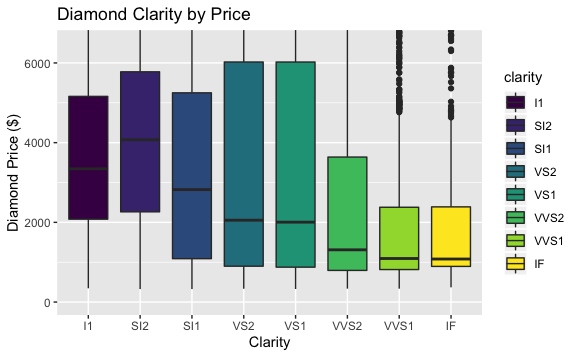

```r
## Student code goes here
library(ggplot2)
ggplot(diamonds, aes(factor(clarity), price, fill=clarity)) + geom_boxplot() + ggtitle("Diamond Clarity by Price") + xlab("Clarity") + ylab("Diamond Price ($)") + coord_cartesian(ylim=c(0,6500))
```

```r
## Student code goes here
```

Show the last 4 rows of data (PART B)

```r
## Student code goes here
print(tail(diamonds, n=4))
```

| carat | cut | color | clarity | depth | table | price | x | y | z |
| --- | --- | --- | --- | --- | --- | --- | --- | --- | --- |
| 0.72 | Good | D | SI1 | 63.1 | 55 | 2757 | 5.69 | 5.75 | 3.61 |
| 0.70 | Very Good | D | SI1 | 62.8 | 60 | 2757 | 5.66 | 5.68 | 3.56 |
| 0.86 | Premium | H | SI2 | 61.0 | 58 | 2757 | 6.15 | 6.12 | 3.74 |
| 0.75 | Ideal | D | SI2 | 62.2 | 55 | 2757 | 5.83 | 5.87 | 3.64 |

```r
## Student code goes here
```

Show the median price (PART C)

```r
## Student code goes here
print(median(diamonds$price))
```

```
[1] 2401
```

```r
## Student code goes here
```

QUESTION 5

Load the Orange dataset, and perform the following analyses. Organize your work and present your answers with separate R Notebook cells.

1. Do a simple scatterplot of Age vs circumference.

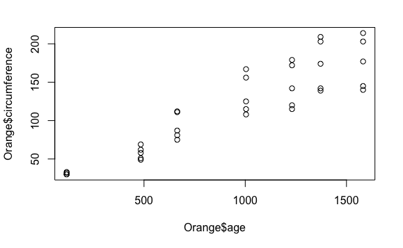

```r
## Student code goes here
data("Orange")
plot(Orange$age,Orange$circumference)
```

```r
## Student code goes here
```

2. Make a stripchart of age

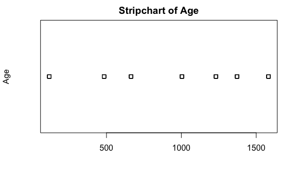

```r
## Student code goes here
stripchart(Orange$age,
           main = "Stripchart of Age",
           ylab = "Age")
```

```r
## Student code goes here
```

3. Change the graph from part (a) as follows:
1. Use orange dots
2. Label the graph exercise one as: – Title = Tree Age vs circumference – X axis = Age – Y axis = circumference of Tree

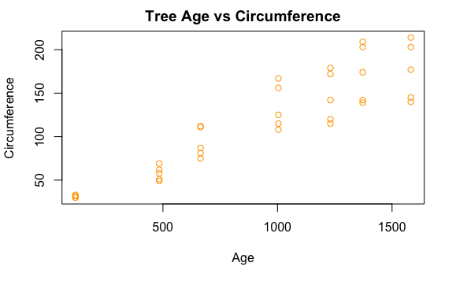

```r
## Student code goes here
plot(Orange$age, Orange$circumference,
     main = "Tree Age vs Circumference",
     xlab = "Age",
     ylab = "Circumference",
     col  = "orange")
```

```r
## Student code goes here
```

QUESTION 6 Using the Diamond dataset again, create a graph that shows the distribution of values for the diamond prices column.

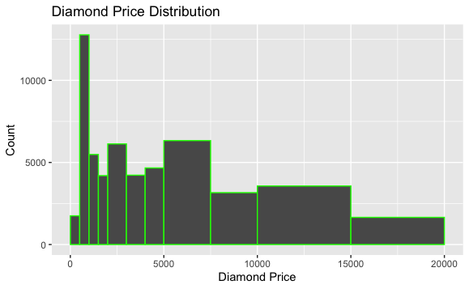

```r
qplot(x = diamonds$price,data = diamonds,
        binwidth = 100,
      breaks = c(0,500,1000,1500,2000,3000,4000,5000,7500,10000,15000,20000),
        xlab = "Diamond Price",
        ylab = "Count",
        main = "Diamond Price Distribution",
        col = I("green"))
```

```r
NA
```